# Estructuras de Datos

Mayo, 2015

## Introducción

Una **Estructura de Datos** es una forma particular de organizar datos en un computador para que puedan ser utilizados de manera eficiente.

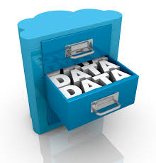

Los datos en R se almacenan como objetos por medio de un nombre. Para enlistar los objetos del área de trabajo usamos los comandos:

```r
ls()
objects()
```

## Estructuras de Datos

- Las estructuras de datos en R se organizan por:
  - **Dimensionalidad,** y
  - **Si son Homogéneos o Heterogéneos**:

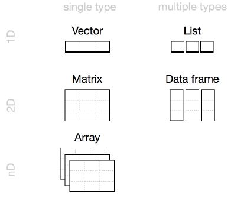

## Estructuras de Datos

**Observaciones.**

- **R** no tiene estructuras **0d (de tipo escalar)**.
  - Los números y strings individuales son considerados como **vectores de longitud 1**.

```r
# no mostrar advertencias
options(warn = -1)
x <- 5
x
```

```
## [1] 5
```

```r
y <- "SSL"
y
```

```
## [1] "SSL"
```

- El texto luego de `#` es un **comentario** (no es interpretado por **R**)
- Para **crear un objeto** se utiliza el operador de **asignación** `<-`

## Vectores

- La estructura de datos básica de R son los vectores, estos se dividen en:
  - **Vectores atómicos.**
  - **Listas.**
- Propiedades Comunes.
- **Tipo (Qué es?).**

```r
    typeof(x)
```

- **Longitud (Número de elementos).**

```r
    length(x)
```

- **Atributos (Metadata).**

```r
    attributes(x)
```

## Vectores atómicos

- Los elementos de un vector atómico son del **mismo tipo**.
- **Tipos comunes:**
  - logical.
  - integer.
  - double (numeric).
  - character.
- Para la creación de vectores recurriremos a una función interna de R, dicha función es conocida con *concatenación* y es denotada por la letra `c()`.

```r
vec <- c(1, 2)
vec
```

```
## [1] 1 2
```

## Creando vectores

La función `vector()` permite crear vectores de un tipo y longitud determinada.

```r
# creamos un vector numerico de longitud 5
vector("numeric", 5)
```

```
## [1] 0 0 0 0 0
```

```r
# creamos un vector logico de longitud 5
vector("logical", 5)
```

```
## [1] FALSE FALSE FALSE FALSE FALSE
```

```r
# creamos un vector de caracteres de longitud 5
vector("character", 5)
```

```
## [1] "" "" "" "" ""
```

## Creando vectores

Una manera más tecnica de crear vectores se realiza por medio de la función `assign()`.

```r
assign("vec", c(2, 4, 6, 8))
vec
```

```
## [1] 2 4 6 8
```

```r
typeof(vec)
```

```
## [1] "double"
```

```r
length(vec)
```

```
## [1] 4
```

```r
attributes(vec)
```

## Elementos de un vector atómico

- La `i-ésima` componente de `vec` se obtiene mediante.

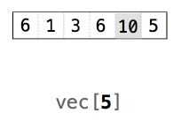

```r
vec[i]
```

```r
vec <- c(6, 1, 3, 6, 10, 5)
vec
```

```
## [1]  6  1  3  6 10  5
```

```r
vec[5]
```

```
## [1] 10
```

## Elementos de un vector atómico

- Para seleccionar varios elementos utilizamos la función `c()`.

```r
vec <- c(6, 1, 3, 6, 10, 5)
# elementos de la posición 2, 4, 6
vec[c(2, 4, 6)]
```

```
## [1] 1 6 5
```

- `TRUE, FALSE` también permiten obtener ciertos elementos:

```r
vec <- c(6, 1, 3, 6, 10, 5)
# elementos de la posición 2, 4, 6
vec[c(FALSE, TRUE, FALSE, TRUE, FALSE, TRUE)]
```

```
## [1] 1 6 5
```

- Utilice `TRUE, FALSE` en lugar de `T, F`.

## Tipos de vectores atómicos

- **Ejemplos:**

```r
# Vector double
dbl_vec <- c(1, 2, -1, 8, 15)
```

```r
# Vector entero
int_vec <- c(3L, 7L, 1L, 14L, 21L) # sufijo L para vector entero
```

```r
# Vector lógico
log_vec <- c(FALSE, TRUE, F, T, TRUE, F) # TRUE y FALSE (T, F) para vector lógico
```

```r
# Vector caracter
chr_vec <- c("Source", "Stat", "Lab", "Ec")
```

## Tipos y Tests

- Para determinar el **tipo de un vector** `vec` utilizamos:

```r
typeof(vec)
```

- Para verificar si un vector `vec` es de un tipo en específico, se utilizan las **funciones "is"**:

```r
is.character(vec)
```

```r
is.double(vec)
```

```r
is.integer(vec)
```

```r
is.logical(vec)
```

## Tipos y Tests

- Ejemplo de un **vector double**.

```r
dbl_vec <- c(1, 2, -1)
dbl_vec
```

```
## [1]  1  2 -1
```

```r
typeof(dbl_vec)
```

```
## [1] "double"
```

```r
is.double(dbl_vec)
```

```
## [1] TRUE
```

```r
is.atomic(dbl_vec)
```

```
## [1] TRUE
```

## Tipos y Tests

- Ejemplo de un **vector integer**.

```r
int_vec <- c(3L, 7L, 1L)
int_vec
```

```
## [1] 3 7 1
```

```r
typeof(int_vec)
```

```
## [1] "integer"
```

```r
is.integer(int_vec)
```

```
## [1] TRUE
```

```r
is.atomic(int_vec)
```

```
## [1] TRUE
```

## Tipos y Tests

- Función `is.numeric()`. Retorna `TRUE` para vectores **double e integer**:

```r
dbl_vec <- c(1, 2, -1.2)
dbl_vec
```

```
## [1]  1.0  2.0 -1.2
```

```r
is.numeric(dbl_vec)
```

```
## [1] TRUE
```

```r
int_vec <- c(3L, 7L, 1L)
int_vec
```

```
## [1] 3 7 1
```

```r
is.numeric(int_vec)
```

```
## [1] TRUE
```

## Modificación elementos

Sabemos que el tamaño de un vector es determinado en su creación, por lo que si se desea añadir o eliminar elementos es necesario reasignar el vector.

```r
vec
```

```
## [1]  6  1  3  6 10  5
```

```r
# agregamos los elementos 15, 18 al final
vec <- c(vec, c(15, 18))
vec
```

```
## [1]  6  1  3  6 10  5 15 18
```

```r
# agregamos el valor de 5 al inicio
vec <- c(5, vec)
vec
```

```
## [1]  5  6  1  3  6 10  5 15 18
```

## Eliminando elementos

Para eliminar ciertos los elementos de un vector usaremos subíndices negativos, lo anterior nos permite excluir los elementos deseados como se muestra a continuación:

```r
vec
```

```
## [1]  5  6  1  3  6 10  5 15 18
```

```r
# eliminamos el valor de la posicion 2
vec <- vec[-2]
vec
```

```
## [1]  5  1  3  6 10  5 15 18
```

```r
# eliminamos los elementos de las posiciones 4, 7
vec <- vec[-c(4, 7)]
vec
```

```
## [1]  5  1  3 10  5 18
```

## Generación de secuencias

El operador ':' genera un vector que abarca un rango de números con salto uniforme de amplitud 1.

```r
1:12
```

```
##  [1]  1  2  3  4  5  6  7  8  9 10 11 12
```

```r
7:-5
```

```
##  [1]  7  6  5  4  3  2  1  0 -1 -2 -3 -4 -5
```

El operador `seq( )` genera secuencias controlando tres parámetros: el inicio, final y salto de la secuencia.

```r
seq(from = 1, to = 12, by = 1)
seq(from = -2, to = 3, by = 0.7)
seq(from = -4, to = 4, length = 12)
```

## Operaciones básicas

A continuación, resumimos las operaciones básicas:

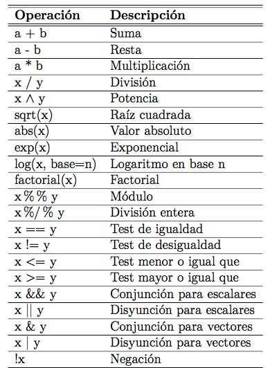

## Coerción

- Los elementos de un vector son del **mismo tipo**.
- Si combinamos tipos diferentes, serán **coercionados al tipo más flexible** dado por la jerarquía:

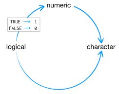

**character \(\leq\) double \(\leq\) integer \(\leq\) logical**

- `TRUE` \(\rightarrow\) `1`.
- `FALSE` \(\rightarrow\) `0`.

## Coerción

```r
vec <- c("ssl", 12, TRUE, FALSE)
vec
```

```
## [1] "ssl"   "12"    "TRUE"  "FALSE"
```

```r
typeof(vec)
```

```
## [1] "character"
```

```r
vec1 <- c(0.5, 2, TRUE, FALSE)
vec1
```

```
## [1] 0.5 2.0 1.0 0.0
```

```r
typeof(vec1)
```

```
## [1] "double"
```

## Coerción

- Las funciones `+, abs, log, etc` coercionan a `double o integer`.

```r
vec <- c(3, 0.5, -6)
vec1 <- abs(vec)
typeof(vec1)
```

```
## [1] "double"
```

```r
vec1 <- c(1L, 3L, -6L)
vec2 <- c(2L, -5L, 9L)
vec3 <- vec1 + vec2
typeof(vec3)
```

```
## [1] "integer"
```

## Coerción

- Las funciones `&, |, any, all, etc` coercionan a `logical`.

```r
vec <- c(TRUE, FALSE, FALSE, TRUE)
(vec1 <- all(vec)) # TRUE si todos sus elementos son TRUE
```

```
## [1] FALSE
```

```r
typeof(vec1)
```

```
## [1] "logical"
```

```r
vec1 <- c(FALSE, TRUE, TRUE, FALSE)
vec2 <- c(TRUE, TRUE, FALSE, FALSE)
(vec3 <- vec1 | vec2)
```

```
## [1]  TRUE  TRUE  TRUE FALSE
```

```r
typeof(vec3)
```

```
## [1] "logical"
```

## Coerción - Funciones "as"

- Para **coercionar** un vector `vec` a un determinado tipo, se utilizan las **funciones "as"** :

```r
as.character(vec)
```

```r
as.double(vec)
```

```r
as.integer(vec)
```

```r
as.logical(vec)
```

```r
as.numeric(vec)
```

## Coerción - Funciones "as"

```r
# coerción directa: double a character
vec <- c(1.7, 5, 8.2, 15.1)
vec1 <- as.character(vec)
vec1
```

```
## [1] "1.7"  "5"    "8.2"  "15.1"
```

```r
typeof(vec1)
```

```
## [1] "character"
```

```r
# coerción directa: logical a character
vec <- c(FALSE, TRUE, FALSE, TRUE, TRUE)
vec1 <- as.character(vec)
vec1
```

```
## [1] "FALSE" "TRUE"  "FALSE" "TRUE"  "TRUE"
```

**character \(\leq\) double \(\leq\) integer \(\leq\) logical**

## Coerción - Funciones "as"

```r
# coerción directa: logical a double
vec <- c(FALSE, TRUE, FALSE, TRUE, TRUE)
vec1 <- as.double(vec)
vec1
```

```
## [1] 0 1 0 1 1
```

- `TRUE` \(\rightarrow\) `1`
- `FALSE` \(\rightarrow\) `0`

```r
sum(vec) # número total de TRUEs
```

```
## [1] 3
```

```r
mean(vec) # proporción de TRUEs
```

```
## [1] 0.6
```

**character \(\leq\) double \(\leq\) integer \(\leq\) logical**

## Coerción - Funciones "as"

```r
# coerción indirecta: character a double
vec <- c("15", "Sin Info", "25", "-")
vec1 <- as.double(vec)
vec1
```

```
## [1] 15 NA 25 NA
```

`NAs introduced by coercion`

```r
# coerción indirecta: character a logical
vec <- c("FALSE", "TRUE", "Sin Info", "-", "TRUE")
vec1 <- as.logical(vec)
vec1
```

```
## [1] FALSE  TRUE    NA    NA  TRUE
```

**character \(\leq\) double \(\leq\) integer \(\leq\) logical**

## Coerción - Funciones "as"

```r
# coerción indirecta: double a logical
vec <- c(1, 0, 17, 3.5, 0)
vec1 <- as.logical(vec)
vec1
```

```
## [1]  TRUE FALSE  TRUE  TRUE FALSE
```

- `== 0` \(\rightarrow\) `FALSE`
- `!= 0` \(\rightarrow\) `TRUE`

**character \(\leq\) double \(\leq\) integer \(\leq\) logical**

## Vectores anidados

- Los **vectores atómicos** pueden ser **anidados**, es decir:

```r
c(1, c(2, c(3,4)))
```

```
## [1] 1 2 3 4
```

- es equivalente a:

```r
c(1, 2, 3, 4)
```

```
## [1] 1 2 3 4
```

## Listas

- Una lista puede contener elementos de **cualquier tipo** y de **distinta longitud**.

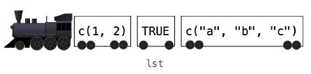

- Para **crear una lista** se utiliza la función `list()` en lugar de `c()`.

```r
lst <- list(c(1, 2), c(TRUE), c("a", "b", "c"))
lst
```

```
## [[1]]
## [1] 1 2
##
## [[2]]
## [1] TRUE
##
## [[3]]
## [1] "a" "b" "c"
```

## Listas

```r
lst <- list(1:3, c("Source", "Stat", "Lab"), c(TRUE, FALSE), c(1.3, 4.5))
typeof(lst)
```

```
## [1] "list"
```

```r
is.atomic(lst)
```

```
## [1] FALSE
```

```r
# probamos si lst es una lista
is.list(lst)
```

```
## [1] TRUE
```

## Coerción

```r
# coerción del vector lst a una lista
lst <- c("ssl", 4, 0.5)
as.list(lst)
```

```
## [[1]]
## [1] "ssl"
##
## [[2]]
## [1] "4"
##
## [[3]]
## [1] "0.5"
```

```r
# coerción de lista a vector (reglas de coerción)
lst <- list(1:3, c("Source", "Stat", "Lab"), c(TRUE, FALSE), c(1.3, 4.5))
unlist(lst)
```

```
##  [1] "1"      "2"      "3"      "Source" "Stat"   "Lab"    "TRUE"
##  [8] "FALSE"  "1.3"    "4.5"
```

## Elementos de una lista

- Para acceder al **elemento** `i` de la lista se utiliza `x[i]`.
- Para acceder al **objeto que contiene el elemento** `i` se utiliza `x[[i]]`.

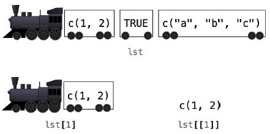

```r
lst <- list(c(1, 2), c(TRUE), c("a", "b", "c"))
lst[1] ; lst[[1]]
```

```
## [[1]]
## [1] 1 2
```

```
## [1] 1 2
```

## Elementos de una lista

```r
lst <- list(1:3, c("Source", "Stat", "Lab"), c(TRUE, FALSE), nomb_obj=c(1.3, 4.5))
lst[4]
```

```
## $nomb_obj
## [1] 1.3 4.5
```

```r
lst[[4]]
```

```
## [1] 1.3 4.5
```

```r
lst$nomb_obj
```

```
## [1] 1.3 4.5
```

## Listas vs vectores atómicos

- Una lista es un **vector recursivo**, es decir una lista puede contener otra lista.

```r
lst <- list(list(c(1,-5), c("a", "b")), list("Source", "Stat"))
str(lst)
```

```
## List of 2
##  $ :List of 2
##   ..$ : num [1:2] 1 -5
##   ..$ : chr [1:2] "a" "b"
##  $ :List of 2
##   ..$ : chr "Source"
##   ..$ : chr "Stat"
```

- Un vector **no puede** contener otro vector:

```r
c(1, c(2, c(3,4)))  ;  c(1, 2, 3, 4)
```

```
## [1] 1 2 3 4
```

```
## [1] 1 2 3 4
```

## Atributos

- Los objetos en R poseen varios **atributos** tales como:
  - names.
  - class.
  - dim, etc.
- La función `attributes(x)` muestra los atributos de un objeto `x`.

**Vector atómico**:

```r
# Vector sin el atributo names
vec <- c(3, 6, -1, 0.5)
attributes(vec)
```

```r
# Vector con el atributo names
vec <- c(a=3, b=6, c=-1, d=0.5)
attributes(vec)
```

```
## $names
## [1] "a" "b" "c" "d"
```

## Atributos

**Lista**:

```r
# Lista sin el atributo names
lst <- list(1:3, c("Source", "Stat", "Lab"), c(TRUE, FALSE))
attributes(lst)
```

```r
# Lista con el atributo names
lst <- list(nomb_obj1=1:3, nomb_obj2=c("Source", "Stat", "Lab"), nomb_obj3=c(TRUE,FALSE))
attributes(lst)
```

```
## $names
## [1] "nomb_obj1" "nomb_obj2" "nomb_obj3"
```

## Atributos

- Para probar que un objeto `x` es un **vector atómico o lista** se utiliza la función:

```r
is.vector(x)
```

- **Observación.**
  - `is.vector(x)` retorna `TRUE` si `x` es un vector con **un solo atributo** (names).

```r
# Vector con el atributo names
vec <- c(a=3, b=6, c=-1, d=0.5)
is.vector(vec)
```

```
## [1] TRUE
```

```r
# Lista con el atributo names
lst <- list(nomb_obj1=1:3, nomb_obj2=c("Source", "Stat", "Lab"), nomb_obj3=c(TRUE,FALSE))
is.vector(lst)
```

```
## [1] TRUE
```

## Matrices

- Una matriz es un **vector** con el **atributo dimensión** `dim`.
- El atributo `dim` es un **vector de longitud 2**: `c(nrow, ncol)`.

```r
mtx <- matrix (1:12,nrow=3, ncol=4, byrow=FALSE)
# se construye por columnas por default (byrow=FALSE)
mtx
```

```
##      [,1] [,2] [,3] [,4]
## [1,]    1    4    7   10
## [2,]    2    5    8   11
## [3,]    3    6    9   12
```

```r
attributes(mtx)
```

```
## $dim
## [1] 3 4
```

## Matrices

- `dim()` se usa para añadir el atributo `dimensión` a un vector, o para hallar la `dimensión` de una matriz.

```r
mtx <- 1:12
mtx
```

```
##  [1]  1  2  3  4  5  6  7  8  9 10 11 12
```

```r
dim(mtx) <- c(3,4)
mtx
```

```
##      [,1] [,2] [,3] [,4]
## [1,]    1    4    7   10
## [2,]    2    5    8   11
## [3,]    3    6    9   12
```

```r
mtx <- matrix (1:12, nrow=3, ncol=4, byrow=FALSE)
dim(mtx)
```

```
## [1] 3 4
```

## Elementos de una matriz

```r
(mtx <- matrix (1:12, nrow=3, ncol=4, byrow=FALSE))
```

```
##      [,1] [,2] [,3] [,4]
## [1,]    1    4    7   10
## [2,]    2    5    8   11
## [3,]    3    6    9   12
```

```r
mtx[1,2] # componente 1, 2
```

```
## [1] 4
```

```r
mtx[,3]  # columna 3
```

```
## [1] 7 8 9
```

```r
mtx[1,]  # fila 1
```

```
## [1]  1  4  7 10
```

## Elementos de una matriz

```r
(mtx <- matrix (1:12, nrow=3, ncol=4, byrow=FALSE))
```

```
##      [,1] [,2] [,3] [,4]
## [1,]    1    4    7   10
## [2,]    2    5    8   11
## [3,]    3    6    9   12
```

```r
mtx[,c(2,4)] # columnas 2 y 4
```

```
##      [,1] [,2]
## [1,]    4   10
## [2,]    5   11
## [3,]    6   12
```

```r
mtx[c(1,3),]  # filas 1 y 3
```

```
##      [,1] [,2] [,3] [,4]
## [1,]    1    4    7   10
## [2,]    3    6    9   12
```